# Lab1-Data Manipulation, Random Number Generation

Zhang Zhixian-3210104129

2023-07-03

# Background

The exponential distribution is defined by its cumulative distribution function
$$F(x) = 1-e^{-\lambda
x}$$
In R, we use **rexp** to generate variables with an exponential distribution.

```
rexp(n=10,rate=5)
```

produces 10 exponentially-distributed numbers with rate $\lambda$ of 5. If the second argument is omitted, the default rate is 1; this is the standard exponential distribution.

# Part 1

1. Generate 200 random values from the standard exponential distribution and store them in a vector exp.draws.1. Find the mean and standard deviation of exp.draws.1.

```r
exp.draws.1 <- rexp(n=200)
mean.exp.draws.1 <- mean(exp.draws.1)
sd.exp.draws.1 <- sd(exp.draws.1)
x <- c(mean.exp.draws.1,sd.exp.draws.1)
print(x)
```

```
## [1] 0.9676028 0.8973591
```

2. Repeat, but change the rate to 0.1, 0.5, 5 and 10, storing the results in vectors called exp.draws.0.1, exp.draws.0.5, exp.draws.5 and exp.draws.10.

```r
rate <- c(0.1,0.5,5,10)
p <- c(paste0('exp.draws.',rate))
p1 <- c(paste0('mean.exp.draws.',rate))
p2 <- c(paste0('sd.exp.draws.',rate))
for (i in 1:4){
  exp.draws <- rexp(n=200,rate=rate[i])
  mean.exp.draws <- mean(exp.draws)
  sd.exp.draws <- sd(exp.draws)
  assign(p[i],exp.draws)
  assign(p1[i],mean.exp.draws)
  assign(p2[i],sd.exp.draws)
}
```

3. The function plot() is the generic function in R for the visual display of data. hist() is a function that takes in and bins data as a side effect. To use this function, we must first specify what we’d like to plot.
1. Use the hist() function to produce a histogram of your standard exponential distribution.

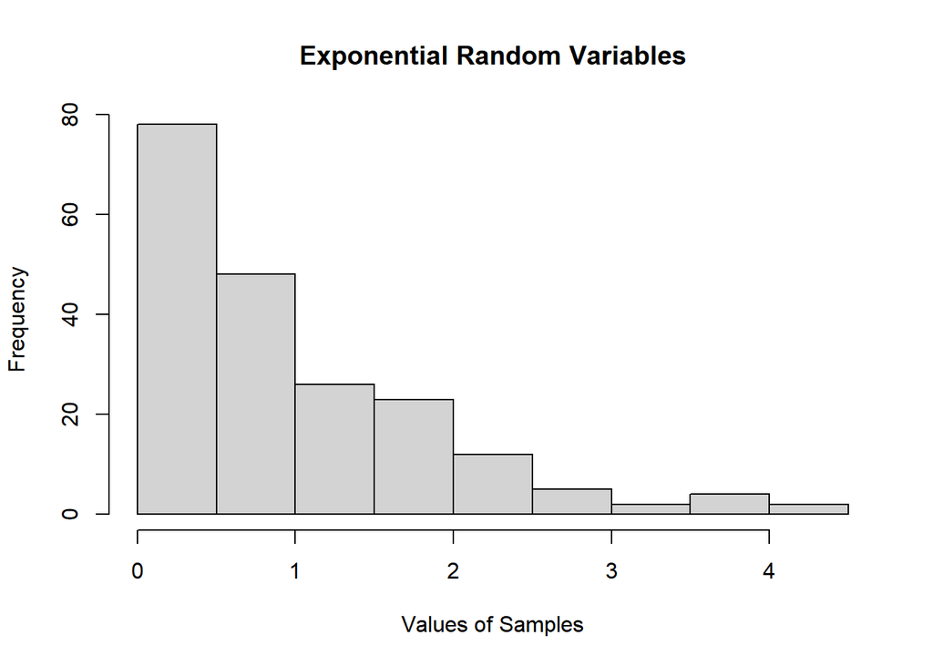

```r
hist(exp.draws.1,main='Exponential Random Variables',xlab='Values of Samples',ylab='Frequency')
```

2. Use plot() with this vector to display the random values from your standard distribution in order.

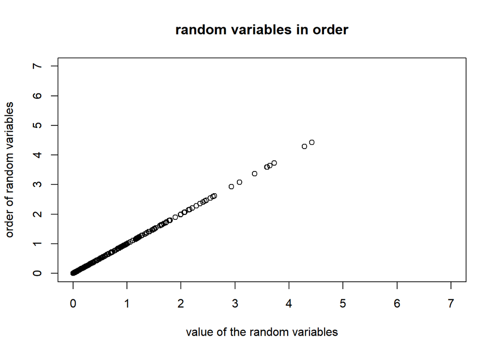

```r
plot(exp.draws.1,exp.draws.1,xlim = c(0,7),ylim = c(0,7),main='random variables in order',xlab='value of the random variables',ylab='order of random variables')
```

c. Now, use plot() with two arguments – any two of your other stored random value vectors – to create a scatterplot of the two vectors against each other.

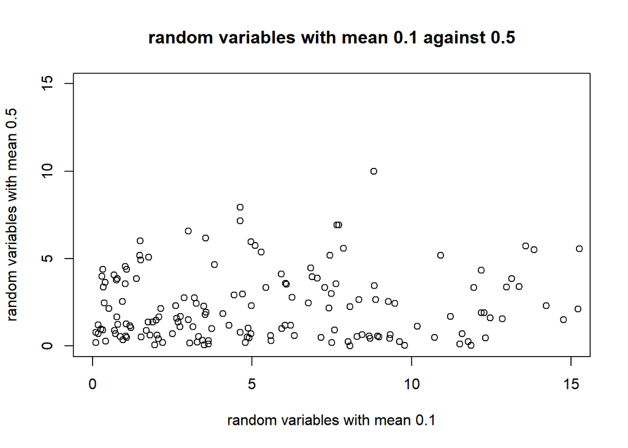

```r
plot(exp.draws.0.1,exp.draws.0.5,xlim = c(0,15),ylim = c(0,15),main='random variables with mean 0.1 against 0.5',xlab='random variables with mean 0.1',ylab='random variables with mean 0.5')
```

4. We’d now like to compare the properties of each of our vectors. Begin by creating a vector of the means of each of our five distributions in the order we created them and saving this to a variable name of your choice.

```r
mean.exp.draws.all <- c(mean.exp.draws.0.1,mean.exp.draws.0.5,mean.exp.draws.1,mean.exp.draws.5,mean.exp.draws.10)
print(mean.exp.draws.all)
```

```
## [1] 9.4174969 2.2174185 0.9676028 0.1751737 0.1054330
```

Using this and other similar vectors, create the following scatterplots. For each plot, explain in words what’s going on.

1. The five means versus the five rates used to generate the distribution.

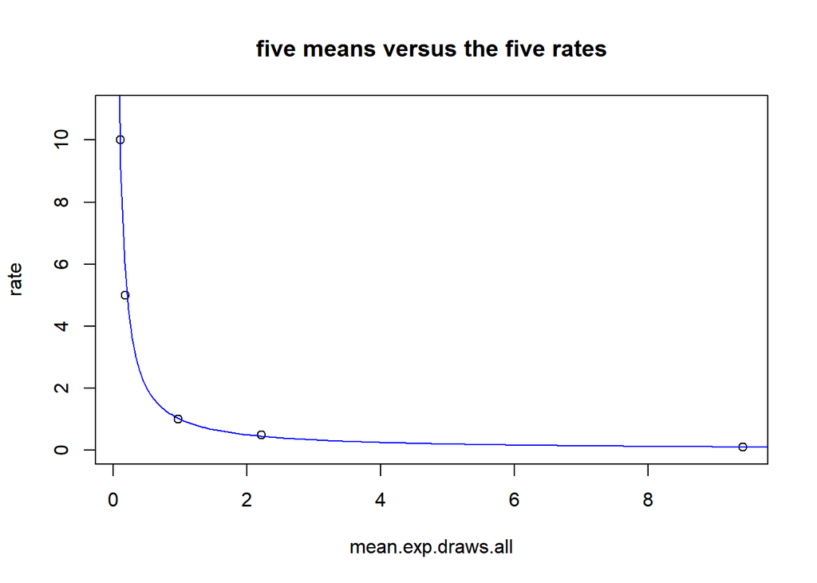

```r
rate <- c(0.1,0.5,1,5,10)
x = seq(0,11,length=200)
plot(mean.exp.draws.all,rate,main='five means versus the five rates',ylim = c(0,11))
lines(x,1/x,col='blue')
```

2. The standard deviations versus the rates.

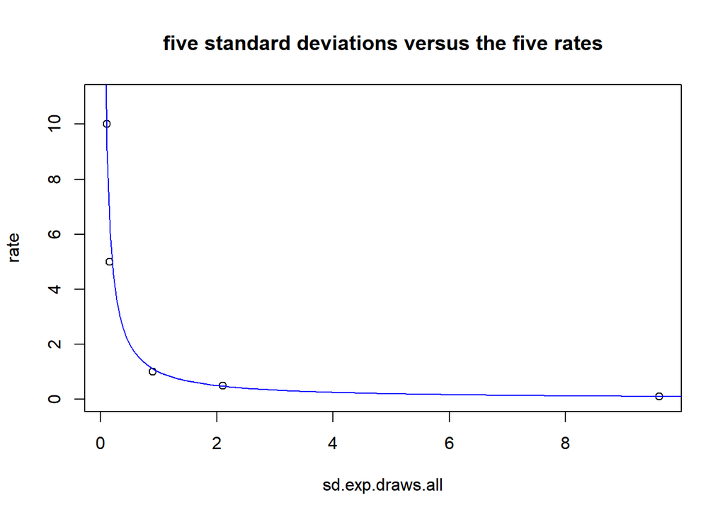

```r
sd.exp.draws.all <- c(sd.exp.draws.0.1,sd.exp.draws.0.5,sd.exp.draws.1,sd.exp.draws.5,sd.exp.draws.10)
plot(sd.exp.draws.all,rate,main='five standard deviations versus the five rates',ylim = c(0,11))
lines(x,1/x,col='blue')
```

3. The means versus the standard deviations.

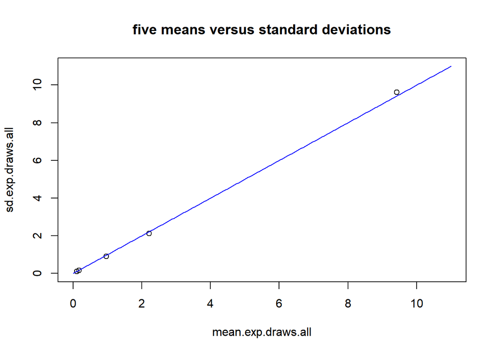

```r
plot(mean.exp.draws.all,sd.exp.draws.all,main='five means versus standard deviations',xlim = c(0,11),ylim = c(0,11))
lines(x,x,col='blue')
```

# Part 2

5. R’s capacity for data and computation is large to what was available 10 years ago.
1. To show this, generate 1.1 million numbers from the standard exponential distribution and store them in a vector called big.exp.draws.1. Calculate the mean and standard deviation.

```r
big.exp.draws.1 <- rexp(n=1100000)
mean.big.exp.draws.1 <- mean(big.exp.draws.1)
sd.big.exp.draws.1 <- sd(big.exp.draws.1)
cat(mean.big.exp.draws.1,sd.big.exp.draws.1)
```

```
## 1.001043 0.999896
```

2. Plot a histogram of big.exp.draws.1. Does it match the function $1 − e^{−x}$ ? Should it? # 后面是在问什么？？

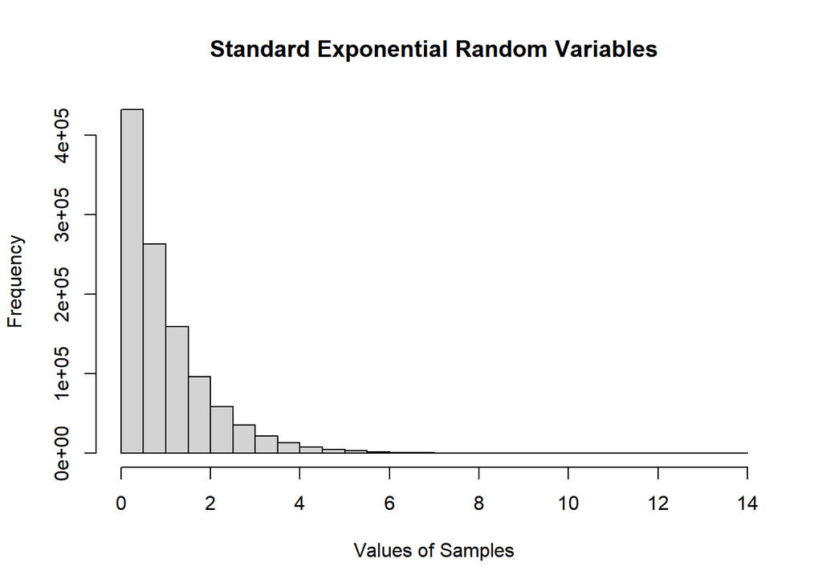

```r
x1 <- hist(big.exp.draws.1,main='Standard Exponential Random Variables',xlab='Values of Samples',ylab='Frequency')
```

```r
x1
```

```
## $breaks
##  [1]  0.0  0.5  1.0  1.5  2.0  2.5  3.0  3.5  4.0  4.5  5.0  5.5  6.0  6.5  7.0
## [16]  7.5  8.0  8.5  9.0  9.5 10.0 10.5 11.0 11.5 12.0 12.5 13.0 13.5 14.0
##
## $counts
##  [1] 431953 262726 159453  96583  58793  35293  21801  13146   8015   4874
## [11]   2900   1807   1045    645    372    247    129     92     57     31
## [21]     12     11      7      6      0      0      0      2
##
## $density
##  [1] 7.853691e-01 4.776836e-01 2.899145e-01 1.756055e-01 1.068964e-01
##  [6] 6.416909e-02 3.963818e-02 2.390182e-02 1.457273e-02 8.861818e-03
## [11] 5.272727e-03 3.285455e-03 1.900000e-03 1.172727e-03 6.763636e-04
## [16] 4.490909e-04 2.345455e-04 1.672727e-04 1.036364e-04 5.636364e-05
## [21] 2.181818e-05 2.000000e-05 1.272727e-05 1.090909e-05 0.000000e+00
## [26] 0.000000e+00 0.000000e+00 3.636364e-06
##
## $mids
##  [1]  0.25  0.75  1.25  1.75  2.25  2.75  3.25  3.75  4.25  4.75  5.25  5.75
## [13]  6.25  6.75  7.25  7.75  8.25  8.75  9.25  9.75 10.25 10.75 11.25 11.75
## [25] 12.25 12.75 13.25 13.75
##
## $xname
## [1] "big.exp.draws.1"
##
## $equidist
## [1] TRUE
##
## attr(,"class")
## [1] "histogram"
```

3. Find the mean of all of the entries in big.exp.draws.1 which are strictly greater than 1. You may need to first create a new vector to identify which elements satisfy this.

```r
bigger.exp.draws.1 = big.exp.draws.1[big.exp.draws.1>1]
mean.bigger.exp.draws.1 <- mean(bigger.exp.draws.1)
print(mean.bigger.exp.draws.1)
```

```
## [1] 1.999849
```

4. Create a matrix, big.exp.draws.1.mat, containing the values in big.exp.draws.1, with 1100 rows and 1000 columns. Use this matrix as the input to the hist() function and save the result to a variable of your choice. What happens to your data? # 发生了什么？？？

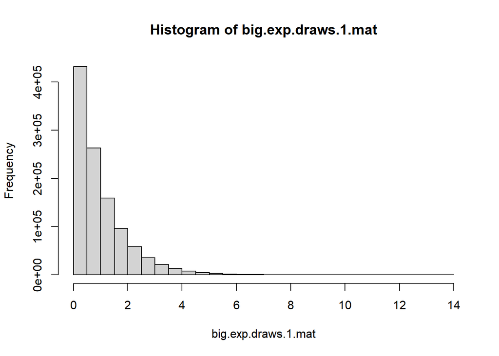

```r
big.exp.draws.1.mat <- array(big.exp.draws.1,dim = c(1100,1000))
x2 <- hist(big.exp.draws.1.mat)
```

```r
x2
```

```
## $breaks
##  [1]  0.0  0.5  1.0  1.5  2.0  2.5  3.0  3.5  4.0  4.5  5.0  5.5  6.0  6.5  7.0
## [16]  7.5  8.0  8.5  9.0  9.5 10.0 10.5 11.0 11.5 12.0 12.5 13.0 13.5 14.0
##
## $counts
##  [1] 431953 262726 159453  96583  58793  35293  21801  13146   8015   4874
## [11]   2900   1807   1045    645    372    247    129     92     57     31
## [21]     12     11      7      6      0      0      0      2
##
## $density
##  [1] 7.853691e-01 4.776836e-01 2.899145e-01 1.756055e-01 1.068964e-01
##  [6] 6.416909e-02 3.963818e-02 2.390182e-02 1.457273e-02 8.861818e-03
## [11] 5.272727e-03 3.285455e-03 1.900000e-03 1.172727e-03 6.763636e-04
## [16] 4.490909e-04 2.345455e-04 1.672727e-04 1.036364e-04 5.636364e-05
## [21] 2.181818e-05 2.000000e-05 1.272727e-05 1.090909e-05 0.000000e+00
## [26] 0.000000e+00 0.000000e+00 3.636364e-06
##
## $mids
##  [1]  0.25  0.75  1.25  1.75  2.25  2.75  3.25  3.75  4.25  4.75  5.25  5.75
## [13]  6.25  6.75  7.25  7.75  8.25  8.75  9.25  9.75 10.25 10.75 11.25 11.75
## [25] 12.25 12.75 13.25 13.75
##
## $xname
## [1] "big.exp.draws.1.mat"
##
## $equidist
## [1] TRUE
##
## attr(,"class")
## [1] "histogram"
```

5. Calculate the mean of the 371st column of big.exp.draws.1.mat.

```r
mean.big.exp.draws.1.mat.371st <- mean(big.exp.draws.1.mat[,371])
print(mean.big.exp.draws.1.mat.371st)
```

```
## [1] 0.9442185
```

6. Now, find the means of all 1000 columns of big.exp.draws.1.mat simultaneously. Plot the histogram of column means. Explain why its shape does not match the histogram in problem 5b).

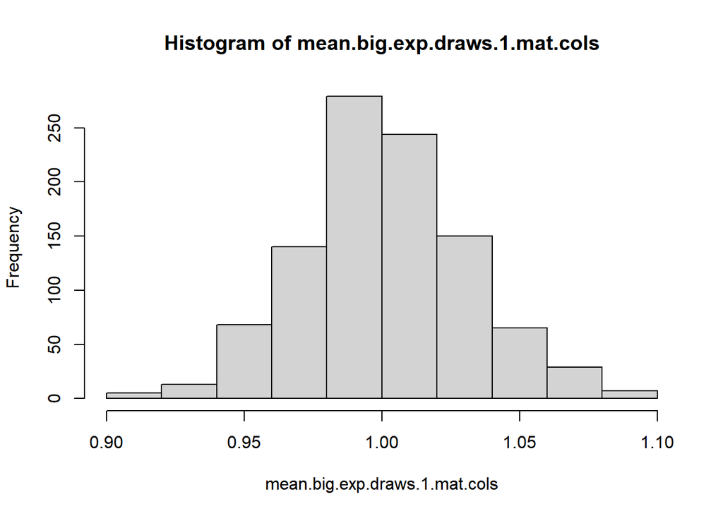

```r
mean.big.exp.draws.1.mat.cols <- apply(big.exp.draws.1.mat,2,mean)
hist(mean.big.exp.draws.1.mat.cols)
```

Explain: First, here we only have 1000 column means, so the number of data is less than that in 5b). Besides, since we generate the means of data, most of the results should be more close to the means of the samples, which is near 1. # 没写完

```r
sqrt.big.exp.draws.1 <- sqrt(big.exp.draws.1)
mean.sqrt.big.exp.draws.1 <- mean(sqrt.big.exp.draws.1)
print(mean.sqrt.big.exp.draws.1)
```

```
## [1] 0.886794
```